# hw03

Xinzhe Dong

September 26, 2017

### 1. Get the maximum and minimum of GDP per capita for all continents.

```r
gapminder %>%
  group_by(continent) %>%
  summarize(min_gdpPercap=min(gdpPercap), max_gdpPercap=max(gdpPercap), range = max_gdpPercap - min_gdpPercap)
```

```
## # A tibble: 5 x 4
##   continent min_gdpPercap max_gdpPercap     range
##      <fctr>         <dbl>         <dbl>     <dbl>
## 1    Africa      241.1659      21951.21  21710.05
## 2  Americas     1201.6372      42951.65  41750.02
## 3      Asia      331.0000     113523.13 113192.13
## 4    Europe      973.5332      49357.19  48383.66
## 5   Oceania    10039.5956      34435.37  24395.77
```

#### Plot the max and min of GDP per capita for all continents.

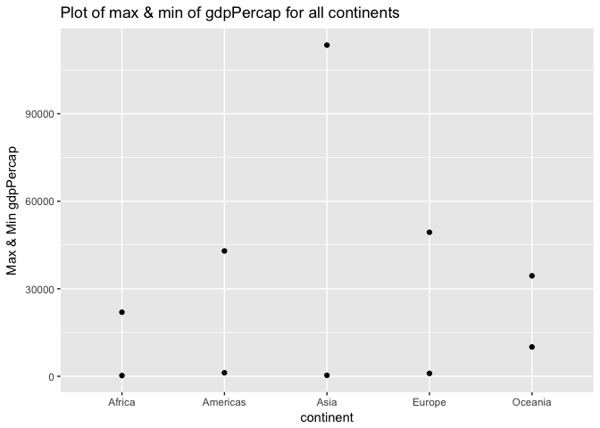

```r
gapminder %>%
  group_by(continent) %>%
  summarize(min_gdpPercap=min(gdpPercap), max_gdpPercap=max(gdpPercap))%>%
  ggplot(aes(x = continent)) +
  geom_point(aes(y = min_gdpPercap)) +
  geom_point(aes(y = max_gdpPercap)) +
  labs(y="Max & Min gdpPercap", title= "Plot of max & min of gdpPercap for all continents")
```

#### We observe the followings:

- Both the maximum and minimum of GDP per capita for Africa is the smallest among the five continents.
- Asia has the largest range of GDP per capita, and the largest maximum of GDP per capita.
- Oceania has the largest minimum gdpPercap.

### 2. Look at the spread of GDP per capita within the continents.

```r
# Statistical summary of gdpPercap within continents
gapminder%>%
  group_by(continent)%>%
  summarize(min_gdpPercap=min(gdpPercap), first_q=quantile(gdpPercap)[2], median_gdpPercap=median(gdpPercap), third_q=quantile(gdpPercap)[4], max_gdpPercap=max(gdpPercap))
```

```
## # A tibble: 5 x 6
##   continent min_gdpPercap   first_q median_gdpPercap   third_q
##      <fctr>         <dbl>     <dbl>            <dbl>     <dbl>
## 1    Africa      241.1659   761.247         1192.138  2377.417
## 2  Americas     1201.6372  3427.779         5465.510  7830.210
## 3      Asia      331.0000  1056.993         2646.787  8549.256
## 4    Europe      973.5332  7213.085        12081.749 20461.386
## 5   Oceania    10039.5956 14141.859        17983.304 22214.117
## # ... with 1 more variables: max_gdpPercap <dbl>
```

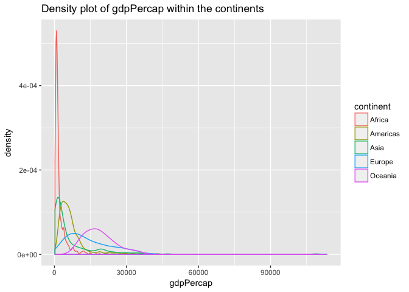

```r
# A density plot of gdpPercap
ggplot(gapminder, aes(x = gdpPercap, color = continent)) + geom_density() +
    labs(title= "Density plot of gdpPercap within the continents")
```

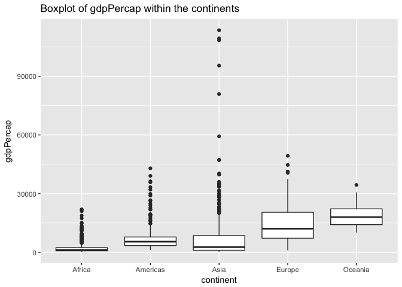

```r
# boxplots of GDP per capita for all continents.
ggplot(gapminder, aes(x = continent, y = gdpPercap)) + geom_boxplot() +
      labs(title= "Boxplot of gdpPercap within the continents")
```

#### From the above two plots, we observe that:

- Oceania has the largest median of gdpPercap among the five continents. Europe has the second largest median of gdpPercap among the five continents.
- Africa has the smallest median of gdpPercap among the five continents.
- The gdpPercap of Asia is more widely spreaded than the other continents.
- The gdpPercap of the five countries are all skewed to the right. The distribution of gdpPercap of Oceania is closer to the normal distribution.

### 3. Compute a weighted mean, weighting by population, of life expectancy for different years.

```r
gapminder %>%
  group_by(year) %>%
  summarize(mean_lifeex=weighted.mean(lifeExp,pop))
```

```
## # A tibble: 12 x 2
##     year mean_lifeex
##    <int>       <dbl>
##  1  1952    48.94424
##  2  1957    52.12189
##  3  1962    52.32438
##  4  1967    56.98431
##  5  1972    59.51478
##  6  1977    61.23726
##  7  1982    62.88176
##  8  1987    64.41635
##  9  1992    65.64590
## 10  1997    66.84934
## 11  2002    67.83904
## 12  2007    68.91909
```

#### Plot the weighted mean of life expectancy vs. year.

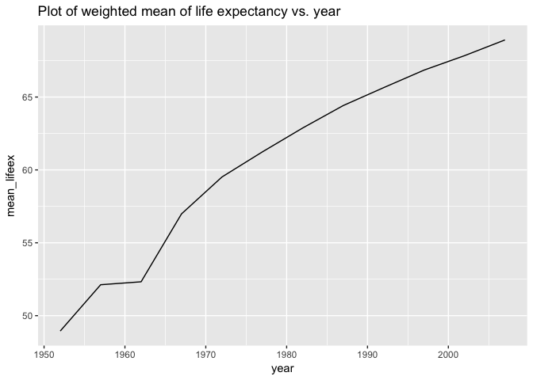

```r
gapminder %>%
  group_by(year) %>%
  summarize(mean_lifeex=weighted.mean(lifeExp,pop)) %>%
  ggplot(aes(x = year, y = mean_lifeex)) + geom_line() +
      labs(title= "Plot of weighted mean of life expectancy vs. year")
```

### 4. How is life expectancy changing over time on different continents?

#### Calculate the mean life expectancy over time on different continents

```r
gapminder %>%
  group_by(continent,year)%>%
  summarize(mean_lifeExp = mean(lifeExp))
```

```
## # A tibble: 60 x 3
## # Groups:   continent [?]
##    continent  year mean_lifeExp
##       <fctr> <int>        <dbl>
##  1    Africa  1952     39.13550
##  2    Africa  1957     41.26635
##  3    Africa  1962     43.31944
##  4    Africa  1967     45.33454
##  5    Africa  1972     47.45094
##  6    Africa  1977     49.58042
##  7    Africa  1982     51.59287
##  8    Africa  1987     53.34479
##  9    Africa  1992     53.62958
## 10    Africa  1997     53.59827
## # ... with 50 more rows
```

#### Plot life expectancy vs. year on different continents

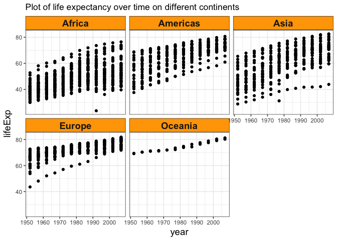

```r
p1 <- ggplot(data = gapminder) +
  geom_point(mapping = aes(x = year, y = lifeExp)) +
  facet_wrap(~ continent, nrow = 2) +
        labs(title= "Plot of life expectancy over time on different continents")

p1 + theme_bw() +
  theme(strip.background = element_rect(fill="orange"),
          axis.title = element_text(size=14),
          strip.text = element_text(size=14, face="bold"))
```

#### We can tell that:

The life expectancy is increasing over time on all the continents.

### 5. Report the absolute and/or relative abundance of countries with low life expectancy over time by continent:

Compute a mean of life expectancy worldwide. Then determine how many countries on each continent have a life expectancy less than the mean life expectancy, for each year.

```r
average_age <- mean(gapminder$lifeExp)
gapminder %>%
  filter(lifeExp<average_age) %>%
    group_by(continent,year) %>%
    summarize(No._countries_with_low_lifeExp=length(country))
```

```
## # A tibble: 40 x 3
## # Groups:   continent [?]
##    continent  year No._countries_with_low_lifeExp
##       <fctr> <int>                          <int>
##  1    Africa  1952                             52
##  2    Africa  1957                             52
##  3    Africa  1962                             51
##  4    Africa  1967                             50
##  5    Africa  1972                             50
##  6    Africa  1977                             49
##  7    Africa  1982                             43
##  8    Africa  1987                             39
##  9    Africa  1992                             38
## 10    Africa  1997                             39
## # ... with 30 more rows
```

#### Note:

- If there is no value for a continent on that year. then it means there is no country that year on that continent has a life expectancy less than the mean life expectancy.
- For example: There is no value for the continent “Oceania” in any year, which means Oceania does not have any country which has a life expectancy less than the mean life expectancy during the whole data collection period.

#### Plot the number of countries with low life expectancy over time by continent.

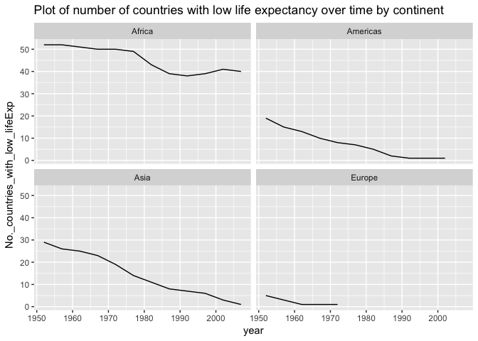

```r
gapminder %>%
  filter(lifeExp<average_age) %>%
    group_by(continent,year) %>%
    summarize(No._countries_with_low_lifeExp=length(country)) %>%
    ggplot(aes(x = year, y = No._countries_with_low_lifeExp)) + geom_line() +
      facet_wrap(~ continent, nrow = 2) +
          labs(title= "Plot of number of countries with low life expectancy over time by continent")
```

### 6. But I want to do more!

#### (1) Get table and figure side-by-side

```r
suppressMessages(library(dplyr))
#devtools::install_github("jennybc/gapminder")
library("gapminder")
gtbl <- tbl_df(gapminder)
```

[output not shown]

| continent | gdpPercap_mean | gdpPercap_median |
| --- | --- | --- |
| Africa | 2193.755 | 1192.138 |
| Americas | 7136.110 | 5465.510 |
| Asia | 7902.150 | 2646.787 |
| Europe | 14469.476 | 12081.749 |
| Oceania | 18621.609 | 17983.304 |

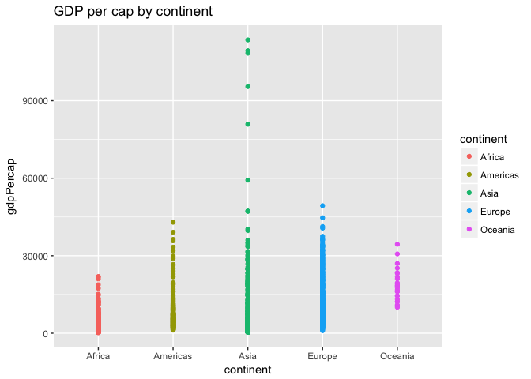

#### (2) Try a table helper package (pander)

```r
gapminder %>%
  filter(country=="Australia", year %in% c(1952,2007 ))%>%
  pandoc.table(style = "grid", caption = "Entries of Australia in 1952 and 2007")
```

```
##
##
## +-----------+-----------+------+---------+----------+-----------+
## |  country  | continent | year | lifeExp |   pop    | gdpPercap |
## +===========+===========+======+=========+==========+===========+
## | Australia |  Oceania  | 1952 |  69.12  | 8691212  |   10040   |
## +-----------+-----------+------+---------+----------+-----------+
## | Australia |  Oceania  | 2007 |  81.23  | 20434176 |   34435   |
## +-----------+-----------+------+---------+----------+-----------+
##
## Table: Entries of Australia in 1952 and 2007
```